# Desafio - EXPANSÃO DE UMA REDE DE LABORATÓRIOS

Desafiante: Leonardo Soares da Costa Tanaka

# 1. Introdução

## 1.1. Cenário

A medicina diagnóstica tem um papel fundamental na jornada de atendimento dos pacientes de qualquer sistema de saúde em qualquer lugar do mundo, sendo somente nos EUA um mercado de aproximadamente 106 bilhões de dólarers com mais de 40 mil laboratórios, empregando mais de 680 mil funcionários segundo a ACLA.

## 1.2. Problema

Diante desse cenário, o desafio proposto tem como objetivo auxiliar a área de negócios de uma rede norte americana de medicina diagnóstica a ter insumos iniciais para suportar seu plano de expansão da rede de laboratórios.

Sabe-se que não é possível ou é bem difícil gerar demanda e fazer ofertas neste tipo de mercado, entretanto é muito interessante e rentável fidelizar o cliente para que ele sempre visite a rede quando surgir a necessidade.

## 1.3. Objetivo

Apresentar e justificar a escolha de TRÊS ZIP CODES para a instalação dos novos laboratórios da rede.

## 1.4. Caminho escolhido

Coletar, tratar e analisar os dados dos laboratórios da rede para separar desses dados os laboratórios que estejam com métricas com valores que sejam interessantes de se ter nos meus novos laboratórios. Então, eu vou encontrar ZIP CODES que possuam características demográficas e econômicas similiares aos ZIP CODES dos laboratórios separados. Assim encontrar os TRÊS ZIP CODES que serão escolhidos como solução do problema em questão.

# 2. Coleta dos dados

Importante: Os dados não estão no repositório do Github, porque excede o limite de dados armazenados permitido.

```python
# Importando as bibliotecas
import pandas as pd
import numpy as np
```

```python
# Coletando as informações geográficas dos laboratórios
df_geo = pd.read_csv("data/df_geocode.csv", index_col=0)
df_geo.head()
```

|  | Lab Id | Address | Location | Zipcode |
| --- | --- | --- | --- | --- |
| 0 | L152 | 3800 PLEASANT HILL RD STE 1, DULUTH, GA 30096 | 34.000319,-84.1629724 | 30096.0 |
| 1 | L520 | 1614 N JAMES ST, ROME, NY 13440 | 43.2311327,-75.4445363 | 13440.0 |
| 2 | L141 | 12911 120TH AVE NE STE D60, KIRKLAND, WA 98034 | 47.7162786,-122.1838152 | 98034.0 |
| 3 | L524 | 5667 PEACHTREE DUNWOODY RD 250, ATLANTA, GA 30342 | 33.9093875,-84.3529096 | 30342.0 |
| 4 | L545 | 1204 IL HWY 164, OQUAWKA, IL 61469 | 40.9309925,-90.9437598 | 61469.0 |

```python
# Coletando os exames de todos os laboratórios
df_exames = pd.read_csv("data/transactional_data.csv", delimiter=";")
df_exames.head()
```

|  | Patient Id | Gender | Date of birth | Date of service | Service Id | Lab Id | CodItem | Testing Cost |
| --- | --- | --- | --- | --- | --- | --- | --- | --- |
| 0 | 10210830256-BIO003 | F | 01/08/1976 00:00:00 | 2019-01-07 | 571904533475-38 | L133 | 70003237 | 9,0 |
| 1 | 10210830256-BIO003 | F | 01/08/1976 00:00:00 | 2019-01-07 | 571904533475-38 | L133 | 70000638 | 13,0 |
| 2 | 10210830256-BIO003 | F | 01/08/1976 00:00:00 | 2019-01-07 | 571904533475-38 | L133 | 70001597 | 49,0 |
| 3 | 10210830256-BIO003 | F | 01/08/1976 00:00:00 | 2019-01-07 | 571904533475-38 | L133 | 70000103 | 11,0 |
| 4 | 10210830256-BIO003 | F | 01/08/1976 00:00:00 | 2019-01-07 | 571904533475-38 | L133 | 70000224 | 10,0 |

```python
df_exames.dtypes
```

```
Patient Id         object
Gender             object
Date of birth      object
Date of service    object
Service Id         object
Lab Id             object
CodItem             int64
Testing Cost       object
dtype: object
```

```python
# Coletando as informações de todos os exames oferecidos pelos laboratórios
df_info_exames = pd.read_csv("data/test_data.csv")
df_info_exames.head()
```

|  | CodItem | Desc Item | Category | Family | Speciality | Testing Cost |
| --- | --- | --- | --- | --- | --- | --- |
| 0 | 70003237 | MAGNESIO, SORO (EXEMPLO DE EXPRESSAO DE RESULT... | CA | CORELAB | BIOCHEMISTRY | 1.78 |
| 1 | 70000638 | HEMOGRAMA, AUTOMATIZADO, SANGUE | CA | HEMATO | BLOOD COUNT | 2.46 |
| 2 | 70001597 | FERRITINA, SORO | CA | CORELAB | IMMUNOHORMONE | 2.11 |
| 3 | 70000103 | FERRO, DOSAGEM, SORO (EXEMPLO DE EXPRESSAO DE ... | CA | CORELAB | BIOCHEMISTRY | 0.80 |
| 4 | 70000224 | CALCIO, DOSAGEM, SORO (EXEMPLO DE EXPRESSAO DE... | CA | CORELAB | BIOCHEMISTRY | 1.02 |

```python
df_info_exames.dtypes
```

```
CodItem           int64
Desc Item        object
Category         object
Family           object
Speciality       object
Testing Cost    float64
dtype: object
```

```python
# Coletando os dados demográficos dos ZIP CODES
df_demographic = pd.read_csv("data/DemographicData_ZCTAs.csv", index_col=0)
df_demographic.head()
```

|  | Id | GeographicAreaName | TotalPopulation | SexRatio(males per 100 females) | Population_Under5Years | Population_5to9Years | Population_10to14Years | Population_15to19Years | Population_20to24Years | Population_25to34Years | Population_35to44Years | Population_45to54Years | Population_55to59Years | Population_60to64Years | Population_65to74Years | Population_75to84Years | Population_85YearsAndOver | MedianAgeInYears |
| --- | --- | --- | --- | --- | --- | --- | --- | --- | --- | --- | --- | --- | --- | --- | --- | --- | --- | --- |
| 0 | 8600000US35004 | ZCTA5 35004 | 12045 | 94.1 | 805 | 1075 | 898 | 477 | 578 | 2088 | 1628 | 1200 | 886 | 683 | 1017 | 534 | 176 | 35.5 |
| 1 | 8600000US35005 | ZCTA5 35005 | 7344 | 86.1 | 504 | 453 | 511 | 499 | 214 | 788 | 795 | 968 | 612 | 561 | 798 | 485 | 156 | 44.0 |
| 2 | 8600000US35006 | ZCTA5 35006 | 2883 | 108.2 | 96 | 153 | 303 | 129 | 156 | 183 | 367 | 430 | 296 | 260 | 280 | 201 | 29 | 47.2 |
| 3 | 8600000US35007 | ZCTA5 35007 | 26332 | 95.0 | 1936 | 1992 | 1837 | 1762 | 1376 | 3119 | 3849 | 3907 | 1665 | 1323 | 2096 | 1106 | 364 | 37.7 |
| 4 | 8600000US35010 | ZCTA5 35010 | 20613 | 90.5 | 1306 | 1465 | 944 | 1217 | 1128 | 2513 | 2106 | 2950 | 1512 | 1472 | 2421 | 1155 | 424 | 42.6 |

```python
df_demographic.dtypes
```

```
Id                                  object
GeographicAreaName                  object
TotalPopulation                      int64
SexRatio(males per 100 females)    float64
Population_Under5Years               int64
Population_5to9Years                 int64
Population_10to14Years               int64
Population_15to19Years               int64
Population_20to24Years               int64
Population_25to34Years               int64
Population_35to44Years               int64
Population_45to54Years               int64
Population_55to59Years               int64
Population_60to64Years               int64
Population_65to74Years               int64
Population_75to84Years               int64
Population_85YearsAndOver            int64
MedianAgeInYears                   float64
dtype: object
```

```python
# Coletando os dados econômicos dos ZIP CODES
df_economic = pd.read_csv("data/EconomicData_ZCTAs.csv", index_col=0)
df_economic.head()
```

|  | id | Geographic Area Name | TotalHouseholds_LessThan$10.000 | TotalHouseholds_$10.000to$14.999 | TotalHouseholds_$15.000to$24.999 | TotalHouseholds_$25.000to$34.999 | TotalHouseholds_$35.000to$49.999 | TotalHouseholds_$50.000to$74.999 | TotalHouseholds_$75.000to$99.999 | TotalHouseholds_$100.000to$149.999 | TotalHouseholds_$150.000to$199.999 | TotalHouseholds_$200.000OrMore |
| --- | --- | --- | --- | --- | --- | --- | --- | --- | --- | --- | --- | --- |
| 0 | 8600000US35004 | ZCTA5 35004 | 198 | 71 | 298 | 513 | 647 | 1117 | 529 | 945 | 245 | 61 |
| 1 | 8600000US35005 | ZCTA5 35005 | 188 | 184 | 318 | 293 | 353 | 562 | 299 | 407 | 67 | 26 |
| 2 | 8600000US35006 | ZCTA5 35006 | 71 | 20 | 117 | 104 | 154 | 176 | 124 | 194 | 51 | 7 |
| 3 | 8600000US35007 | ZCTA5 35007 | 396 | 208 | 670 | 462 | 1173 | 1854 | 1578 | 2224 | 473 | 254 |
| 4 | 8600000US35010 | ZCTA5 35010 | 700 | 610 | 1093 | 957 | 1056 | 1512 | 807 | 749 | 254 | 249 |

```python
df_economic.dtypes
```

```
id                                    object
Geographic Area Name                  object
TotalHouseholds_LessThan$10.000        int64
TotalHouseholds_$10.000to$14.999       int64
TotalHouseholds_$15.000to$24.999       int64
TotalHouseholds_$25.000to$34.999       int64
TotalHouseholds_$35.000to$49.999       int64
TotalHouseholds_$50.000to$74.999       int64
TotalHouseholds_$75.000to$99.999       int64
TotalHouseholds_$100.000to$149.999     int64
TotalHouseholds_$150.000to$199.999     int64
TotalHouseholds_$200.000OrMore         int64
dtype: object
```

# 2. Tratamento dos dados

```python
df_geo.head()
```

|  | Lab Id | Address | Location | Zipcode |
| --- | --- | --- | --- | --- |
| 0 | L152 | 3800 PLEASANT HILL RD STE 1, DULUTH, GA 30096 | 34.000319,-84.1629724 | 30096.0 |
| 1 | L520 | 1614 N JAMES ST, ROME, NY 13440 | 43.2311327,-75.4445363 | 13440.0 |
| 2 | L141 | 12911 120TH AVE NE STE D60, KIRKLAND, WA 98034 | 47.7162786,-122.1838152 | 98034.0 |
| 3 | L524 | 5667 PEACHTREE DUNWOODY RD 250, ATLANTA, GA 30342 | 33.9093875,-84.3529096 | 30342.0 |
| 4 | L545 | 1204 IL HWY 164, OQUAWKA, IL 61469 | 40.9309925,-90.9437598 | 61469.0 |

```python
df_geo.dtypes
```

```
Lab Id       object
Address      object
Location     object
Zipcode     float64
dtype: object
```

```python
# Descobrir onde existem valores nulos no Dataframe e onde estão
df_geo.isnull().sum()
```

```
Lab Id      0
Address     0
Location    0
Zipcode     1
dtype: int64
```

```python
# Removendo as colunas nulas
df_geo = df_geo.dropna(axis=0)
```

```python
# Pegando as informações limpas do Dataframe de informações geográficas dos laboratórios para um Dataframe dos laboratórios
df_labs = df_geo[["Zipcode", "Lab Id", "Address"]]
df_labs.head()
```

|  | Zipcode | Lab Id | Address |
| --- | --- | --- | --- |
| 0 | 30096.0 | L152 | 3800 PLEASANT HILL RD STE 1, DULUTH, GA 30096 |
| 1 | 13440.0 | L520 | 1614 N JAMES ST, ROME, NY 13440 |
| 2 | 98034.0 | L141 | 12911 120TH AVE NE STE D60, KIRKLAND, WA 98034 |
| 3 | 30342.0 | L524 | 5667 PEACHTREE DUNWOODY RD 250, ATLANTA, GA 30342 |
| 4 | 61469.0 | L545 | 1204 IL HWY 164, OQUAWKA, IL 61469 |

```python
# Separar a coluna Location em duas Colunas de Latitude e Longitude
lat = []
lon = []
for location in df_geo["Location"]:
    lat_lon = location.split(",")
    lat.append(float(lat_lon[0]))
    lon.append(float(lat_lon[1]))
df_labs["Lat"] = lat
df_labs["Lon"] = lon
df_labs.head()
```

|  | Zipcode | Lab Id | Address | Lat | Lon |
| --- | --- | --- | --- | --- | --- |
| 0 | 30096.0 | L152 | 3800 PLEASANT HILL RD STE 1, DULUTH, GA 30096 | 34.000319 | -84.162972 |
| 1 | 13440.0 | L520 | 1614 N JAMES ST, ROME, NY 13440 | 43.231133 | -75.444536 |
| 2 | 98034.0 | L141 | 12911 120TH AVE NE STE D60, KIRKLAND, WA 98034 | 47.716279 | -122.183815 |
| 3 | 30342.0 | L524 | 5667 PEACHTREE DUNWOODY RD 250, ATLANTA, GA 30342 | 33.909388 | -84.352910 |
| 4 | 61469.0 | L545 | 1204 IL HWY 164, OQUAWKA, IL 61469 | 40.930993 | -90.943760 |

```python
# Unir os dataframes pela coluna CodItem
df_exames = pd.merge(df_exames, df_info_exames, on='CodItem')
df_exames.head()
```

|  | Patient Id | Gender | Date of birth | Date of service | Service Id | Lab Id | CodItem | Testing Cost_x | Desc Item | Category | Family | Speciality | Testing Cost_y |
| --- | --- | --- | --- | --- | --- | --- | --- | --- | --- | --- | --- | --- | --- |
| 0 | 10210830256-BIO003 | F | 01/08/1976 00:00:00 | 2019-01-07 | 571904533475-38 | L133 | 70003237 | 9,0 | MAGNESIO, SORO (EXEMPLO DE EXPRESSAO DE RESULT... | CA | CORELAB | BIOCHEMISTRY | 1.78 |
| 1 | 10225666807-BIO002 | F | 16/07/1968 00:00:00 | 2019-01-15 | 573103867832-51 | L139 | 70003237 | 9,0 | MAGNESIO, SORO (EXEMPLO DE EXPRESSAO DE RESULT... | CA | CORELAB | BIOCHEMISTRY | 1.78 |
| 2 | 571700011536-BIO002 | F | 17/04/1961 00:00:00 | 2019-01-04 | 571706608210-36 | L131 | 70003237 | 9,0 | MAGNESIO, SORO (EXEMPLO DE EXPRESSAO DE RESULT... | CA | CORELAB | BIOCHEMISTRY | 1.78 |
| 3 | 574400001820-BIO002 | F | 01/04/1966 00:00:00 | 2019-01-17 | 574400919309-64 | L150 | 70003237 | 9,0 | MAGNESIO, SORO (EXEMPLO DE EXPRESSAO DE RESULT... | CA | CORELAB | BIOCHEMISTRY | 1.78 |
| 4 | 10210855836-BIO003 | F | 25/12/1980 00:00:00 | 2019-02-08 | 575007148185-72 | L155 | 70003237 | 9,0 | MAGNESIO, SORO (EXEMPLO DE EXPRESSAO DE RESULT... | CA | CORELAB | BIOCHEMISTRY | 1.78 |

```python
# Descobrir os gêneros existentes
df_exames["Gender"].unique()
```

```
array(['F', 'M', 'I'], dtype=object)
```

```python
# Transformar a coluna Testing Cost de string para float
testing_costs = []
for cost in df_exames["Testing Cost_x"]:
    testing_costs.append(float(cost.replace(',', '.')))
df_exames["Testing Cost_x"] = testing_costs
# Calcular o quantidade de clientes para cada laboratório
qtd_clientes = df_exames.groupby('Lab Id')['Patient Id'].nunique()
# Calcular o valor total para cada laboratório
df_exames_total = df_exames.groupby('Lab Id')['Testing Cost_x'].sum()
# Calcular o quantidade de exames para cada laboratório
df_exames_count = df_exames.groupby('Lab Id')['Testing Cost_x'].count()
# Calcular o ticket médio para cada laboratório
df_exames_mean = df_exames.groupby('Lab Id')['Testing Cost_x'].mean()
# Calcular o quantidade de exames para mulheres
df_exames_mulheres = df_exames[df_exames["Gender"] == "F"].groupby('Lab Id')['Gender'].count()
# Calcular o quantidade de exames para homens
df_exames_homens = df_exames[df_exames["Gender"] == "M"].groupby('Lab Id')['Gender'].count()
# Calcular o valor total gasto para cada laboratório
df_exames_total_cost = df_exames.groupby('Lab Id')['Testing Cost_y'].sum()
# Calcular o custo médio para cada laboratório
df_exames_mean_cost = df_exames.groupby('Lab Id')['Testing Cost_y'].mean()
# Calcular o quantidade de exames diferentes
qtd_exames_por_lab = df_exames.groupby('Lab Id')['CodItem'].nunique()
# Calcular o quantidade de categorias diferentes
qtd_categorias_por_lab = df_exames.groupby('Lab Id')['Category'].nunique()
# Calcular o quantidade de famílias diferentes
qtd_familias_por_lab = df_exames.groupby('Lab Id')['Family'].nunique()
# Calcular o quantidade de especialidades diferentes
qtd_especialidades_por_lab = df_exames.groupby('Lab Id')['Speciality'].nunique()
```

```python
# Juntar os resultados em um único dataframe
df_resultado = pd.concat([qtd_clientes, df_exames_total, df_exames_count, df_exames_mean, df_exames_mulheres, df_exames_homens,
                          df_exames_total_cost, df_exames_mean_cost, qtd_exames_por_lab, qtd_categorias_por_lab, qtd_familias_por_lab, qtd_especialidades_por_lab], axis=1)
df_resultado.columns = ['Qtd de Clientes', 'Faturamento', 'Qtd de Exames', 'Ticket Médio', "Qtd de Exames para Mulheres", "Qtd de Exames para Homens",
                        "Custo Total", "Custo Médio", "Qtd de Exames Diferentes", "Qtd de Categorias Diferentes", "Qtd de Famílias Diferentes", "Qtd de Especialidades Diferentes"]
# Juntar com o dataframe dos laboratórios
df_labs = df_labs.merge(df_resultado, left_on='Lab Id', right_index=True)
df_labs[["Zipcode", "Lab Id", "Qtd de Clientes", "Faturamento", "Qtd de Exames", "Ticket Médio", "Qtd de Exames para Mulheres", "Qtd de Exames para Homens",
         "Custo Total", "Custo Médio", "Qtd de Exames Diferentes", "Qtd de Categorias Diferentes", "Qtd de Famílias Diferentes", "Qtd de Especialidades Diferentes"]].head()
```

|  | Zipcode | Lab Id | Qtd de Clientes | Faturamento | Qtd de Exames | Ticket Médio | Qtd de Exames para Mulheres | Qtd de Exames para Homens | Custo Total | Custo Médio | Qtd de Exames Diferentes | Qtd de Categorias Diferentes | Qtd de Famílias Diferentes | Qtd de Especialidades Diferentes |
| --- | --- | --- | --- | --- | --- | --- | --- | --- | --- | --- | --- | --- | --- | --- |
| 0 | 30096.0 | L152 | 22016 | 6255437.62 | 95828 | 65.277765 | 62247 | 33581 | 2512512.65 | 26.218982 | 938 | 6 | 21 | 67 |
| 1 | 13440.0 | L520 | 3815 | 582095.96 | 20561 | 28.310683 | 12989 | 7572 | 79524.27 | 3.867724 | 456 | 3 | 11 | 36 |
| 2 | 98034.0 | L141 | 11937 | 2800703.10 | 51051 | 54.860886 | 35767 | 15284 | 1103809.48 | 21.621701 | 670 | 5 | 16 | 53 |
| 3 | 30342.0 | L524 | 2771 | 367192.36 | 13257 | 27.697998 | 8253 | 5004 | 43226.04 | 3.260620 | 343 | 2 | 10 | 32 |
| 4 | 61469.0 | L545 | 471 | 88457.00 | 2823 | 31.334396 | 1717 | 1106 | 9643.79 | 3.416149 | 237 | 2 | 10 | 29 |

```python
# Coeficiente de Custo é Custo Total dividido pelo Faturamento
df_labs["Coeficiente de Custo"] = df_labs["Custo Total"]/df_labs["Faturamento"]
df_labs[["Zipcode", "Lab Id", "Coeficiente de Custo"]].head()
```

|  | Zipcode | Lab Id | Coeficiente de Custo |
| --- | --- | --- | --- |
| 0 | 30096.0 | L152 | 0.401653 |
| 1 | 13440.0 | L520 | 0.136617 |
| 2 | 98034.0 | L141 | 0.394119 |
| 3 | 30342.0 | L524 | 0.117720 |
| 4 | 61469.0 | L545 | 0.109022 |

```python
# Remover linhas duplicadas
df_demographic = df_demographic.drop_duplicates()
df_demographic.head()
```

|  | Id | GeographicAreaName | TotalPopulation | SexRatio(males per 100 females) | Population_Under5Years | Population_5to9Years | Population_10to14Years | Population_15to19Years | Population_20to24Years | Population_25to34Years | Population_35to44Years | Population_45to54Years | Population_55to59Years | Population_60to64Years | Population_65to74Years | Population_75to84Years | Population_85YearsAndOver | MedianAgeInYears |
| --- | --- | --- | --- | --- | --- | --- | --- | --- | --- | --- | --- | --- | --- | --- | --- | --- | --- | --- |
| 0 | 8600000US35004 | ZCTA5 35004 | 12045 | 94.1 | 805 | 1075 | 898 | 477 | 578 | 2088 | 1628 | 1200 | 886 | 683 | 1017 | 534 | 176 | 35.5 |
| 1 | 8600000US35005 | ZCTA5 35005 | 7344 | 86.1 | 504 | 453 | 511 | 499 | 214 | 788 | 795 | 968 | 612 | 561 | 798 | 485 | 156 | 44.0 |
| 2 | 8600000US35006 | ZCTA5 35006 | 2883 | 108.2 | 96 | 153 | 303 | 129 | 156 | 183 | 367 | 430 | 296 | 260 | 280 | 201 | 29 | 47.2 |
| 3 | 8600000US35007 | ZCTA5 35007 | 26332 | 95.0 | 1936 | 1992 | 1837 | 1762 | 1376 | 3119 | 3849 | 3907 | 1665 | 1323 | 2096 | 1106 | 364 | 37.7 |
| 4 | 8600000US35010 | ZCTA5 35010 | 20613 | 90.5 | 1306 | 1465 | 944 | 1217 | 1128 | 2513 | 2106 | 2950 | 1512 | 1472 | 2421 | 1155 | 424 | 42.6 |

```python
# Remover linhas duplicadas
df_economic = df_economic.drop_duplicates()
df_economic.head()
```

|  | id | Geographic Area Name | TotalHouseholds_LessThan$10.000 | TotalHouseholds_$10.000to$14.999 | TotalHouseholds_$15.000to$24.999 | TotalHouseholds_$25.000to$34.999 | TotalHouseholds_$35.000to$49.999 | TotalHouseholds_$50.000to$74.999 | TotalHouseholds_$75.000to$99.999 | TotalHouseholds_$100.000to$149.999 | TotalHouseholds_$150.000to$199.999 | TotalHouseholds_$200.000OrMore |
| --- | --- | --- | --- | --- | --- | --- | --- | --- | --- | --- | --- | --- |
| 0 | 8600000US35004 | ZCTA5 35004 | 198 | 71 | 298 | 513 | 647 | 1117 | 529 | 945 | 245 | 61 |
| 1 | 8600000US35005 | ZCTA5 35005 | 188 | 184 | 318 | 293 | 353 | 562 | 299 | 407 | 67 | 26 |
| 2 | 8600000US35006 | ZCTA5 35006 | 71 | 20 | 117 | 104 | 154 | 176 | 124 | 194 | 51 | 7 |
| 3 | 8600000US35007 | ZCTA5 35007 | 396 | 208 | 670 | 462 | 1173 | 1854 | 1578 | 2224 | 473 | 254 |
| 4 | 8600000US35010 | ZCTA5 35010 | 700 | 610 | 1093 | 957 | 1056 | 1512 | 807 | 749 | 254 | 249 |

```python
# Juntando o Dataframe dos ZIP CODES demográficos e econômicos em um mesmo Dataframe
df_demographic.rename(columns={'GeographicAreaName': 'Geographic Area Name'}, inplace = True)
df_zip_codes = pd.merge(df_demographic, df_economic, on="Geographic Area Name", how="inner")
df_zip_codes = df_zip_codes[(df_zip_codes["Geographic Area Name"].isin(df_demographic["Geographic Area Name"])) &
                            (df_zip_codes["Geographic Area Name"].isin(df_economic["Geographic Area Name"]))]
print(len(df_zip_codes))
df_zip_codes.head()
```

```
33120
```

|  | Id | Geographic Area Name | TotalPopulation | SexRatio(males per 100 females) | Population_Under5Years | Population_5to9Years | Population_10to14Years | Population_15to19Years | Population_20to24Years | Population_25to34Years | ... | TotalHouseholds_LessThan$10.000 | TotalHouseholds_$10.000to$14.999 | TotalHouseholds_$15.000to$24.999 | TotalHouseholds_$25.000to$34.999 | TotalHouseholds_$35.000to$49.999 | TotalHouseholds_$50.000to$74.999 | TotalHouseholds_$75.000to$99.999 | TotalHouseholds_$100.000to$149.999 | TotalHouseholds_$150.000to$199.999 | TotalHouseholds_$200.000OrMore |
| --- | --- | --- | --- | --- | --- | --- | --- | --- | --- | --- | --- | --- | --- | --- | --- | --- | --- | --- | --- | --- | --- |
| 0 | 8600000US35004 | ZCTA5 35004 | 12045 | 94.1 | 805 | 1075 | 898 | 477 | 578 | 2088 | ... | 198 | 71 | 298 | 513 | 647 | 1117 | 529 | 945 | 245 | 61 |
| 1 | 8600000US35005 | ZCTA5 35005 | 7344 | 86.1 | 504 | 453 | 511 | 499 | 214 | 788 | ... | 188 | 184 | 318 | 293 | 353 | 562 | 299 | 407 | 67 | 26 |
| 2 | 8600000US35006 | ZCTA5 35006 | 2883 | 108.2 | 96 | 153 | 303 | 129 | 156 | 183 | ... | 71 | 20 | 117 | 104 | 154 | 176 | 124 | 194 | 51 | 7 |
| 3 | 8600000US35007 | ZCTA5 35007 | 26332 | 95.0 | 1936 | 1992 | 1837 | 1762 | 1376 | 3119 | ... | 396 | 208 | 670 | 462 | 1173 | 1854 | 1578 | 2224 | 473 | 254 |
| 4 | 8600000US35010 | ZCTA5 35010 | 20613 | 90.5 | 1306 | 1465 | 944 | 1217 | 1128 | 2513 | ... | 700 | 610 | 1093 | 957 | 1056 | 1512 | 807 | 749 | 254 | 249 |

5 rows × 29 columns

```python
df_zip_codes.columns
```

```
Index(['Id', 'Geographic Area Name', 'TotalPopulation',
       'SexRatio(males per 100 females)', 'Population_Under5Years',
       'Population_5to9Years', 'Population_10to14Years',
       'Population_15to19Years', 'Population_20to24Years',
       'Population_25to34Years', 'Population_35to44Years',
       'Population_45to54Years', 'Population_55to59Years',
       'Population_60to64Years', 'Population_65to74Years',
       'Population_75to84Years', 'Population_85YearsAndOver',
       'MedianAgeInYears', 'id', 'TotalHouseholds_LessThan$10.000',
       'TotalHouseholds_$10.000to$14.999', 'TotalHouseholds_$15.000to$24.999',
       'TotalHouseholds_$25.000to$34.999', 'TotalHouseholds_$35.000to$49.999',
       'TotalHouseholds_$50.000to$74.999', 'TotalHouseholds_$75.000to$99.999',
       'TotalHouseholds_$100.000to$149.999',
       'TotalHouseholds_$150.000to$199.999', 'TotalHouseholds_$200.000OrMore'],
      dtype='object')
```

```python
# Removendo colunas que não ajudam na Análise
df_zip_codes.drop(columns=["Id", "id"], inplace=True)
df_zip_codes.columns
```

```
Index(['Geographic Area Name', 'TotalPopulation',
       'SexRatio(males per 100 females)', 'Population_Under5Years',
       'Population_5to9Years', 'Population_10to14Years',
       'Population_15to19Years', 'Population_20to24Years',
       'Population_25to34Years', 'Population_35to44Years',
       'Population_45to54Years', 'Population_55to59Years',
       'Population_60to64Years', 'Population_65to74Years',
       'Population_75to84Years', 'Population_85YearsAndOver',
       'MedianAgeInYears', 'TotalHouseholds_LessThan$10.000',
       'TotalHouseholds_$10.000to$14.999', 'TotalHouseholds_$15.000to$24.999',
       'TotalHouseholds_$25.000to$34.999', 'TotalHouseholds_$35.000to$49.999',
       'TotalHouseholds_$50.000to$74.999', 'TotalHouseholds_$75.000to$99.999',
       'TotalHouseholds_$100.000to$149.999',
       'TotalHouseholds_$150.000to$199.999', 'TotalHouseholds_$200.000OrMore'],
      dtype='object')
```

```python
# Passar a coluna que possui os ZIP CODES de string para float
zip_code = []
for location in df_zip_codes["Geographic Area Name"]:
    zip_string = location.split(" ")
    zip_code.append(float(zip_string[1]))
df_zip_codes["Geographic Area Name"] = zip_code
df_zip_codes.head()
```

|  | Geographic Area Name | TotalPopulation | SexRatio(males per 100 females) | Population_Under5Years | Population_5to9Years | Population_10to14Years | Population_15to19Years | Population_20to24Years | Population_25to34Years | Population_35to44Years | ... | TotalHouseholds_LessThan$10.000 | TotalHouseholds_$10.000to$14.999 | TotalHouseholds_$15.000to$24.999 | TotalHouseholds_$25.000to$34.999 | TotalHouseholds_$35.000to$49.999 | TotalHouseholds_$50.000to$74.999 | TotalHouseholds_$75.000to$99.999 | TotalHouseholds_$100.000to$149.999 | TotalHouseholds_$150.000to$199.999 | TotalHouseholds_$200.000OrMore |
| --- | --- | --- | --- | --- | --- | --- | --- | --- | --- | --- | --- | --- | --- | --- | --- | --- | --- | --- | --- | --- | --- |
| 0 | 35004.0 | 12045 | 94.1 | 805 | 1075 | 898 | 477 | 578 | 2088 | 1628 | ... | 198 | 71 | 298 | 513 | 647 | 1117 | 529 | 945 | 245 | 61 |
| 1 | 35005.0 | 7344 | 86.1 | 504 | 453 | 511 | 499 | 214 | 788 | 795 | ... | 188 | 184 | 318 | 293 | 353 | 562 | 299 | 407 | 67 | 26 |
| 2 | 35006.0 | 2883 | 108.2 | 96 | 153 | 303 | 129 | 156 | 183 | 367 | ... | 71 | 20 | 117 | 104 | 154 | 176 | 124 | 194 | 51 | 7 |
| 3 | 35007.0 | 26332 | 95.0 | 1936 | 1992 | 1837 | 1762 | 1376 | 3119 | 3849 | ... | 396 | 208 | 670 | 462 | 1173 | 1854 | 1578 | 2224 | 473 | 254 |
| 4 | 35010.0 | 20613 | 90.5 | 1306 | 1465 | 944 | 1217 | 1128 | 2513 | 2106 | ... | 700 | 610 | 1093 | 957 | 1056 | 1512 | 807 | 749 | 254 | 249 |

5 rows × 27 columns

# 3. Análise dos dados dos laboratórios atuais

```python
# Importando as bibliotecas
import matplotlib.pyplot as plt
import seaborn as sns
```

## Distribuição geográfica dos laboratórios

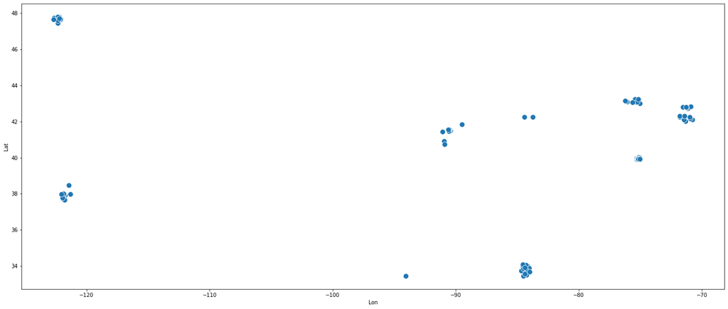

```python
plt.figure(figsize=(24, 10))
geo = sns.scatterplot(data=df_labs, x="Lon", y="Lat", s=100)
```

- Pontos mais concentrados indicam laboratórios com grande grau de competitividade, possuem uma maior quantidade de clientes e um valor mais caro para os exames;
- Pontos menos concentrados indicam laboratórios com pequeno grau de competitividade, possuem uma menor quantidade de clientes e um valor mais barato para os exames.

## Quantidade de clientes por laboratório

```
<function matplotlib.pyplot.show(close=None, block=None)>
```

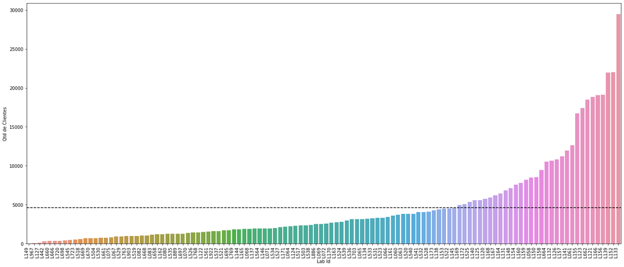

```python
media_qtd_clientes = df_labs["Qtd de Clientes"].mean()
plt.figure(figsize=(24, 10))
geo = sns.barplot(data=df_labs.sort_values(by="Qtd de Clientes"), x="Lab Id", y="Qtd de Clientes")
plt.axhline(media_qtd_clientes, 0, 1, color="black", **{"ls": "--"})
plt.setp(plt.gca().get_xticklabels(), rotation=90, horizontalalignment='right')
plt.show
```

## Faturamento por laboratório

```
<function matplotlib.pyplot.show(close=None, block=None)>
```

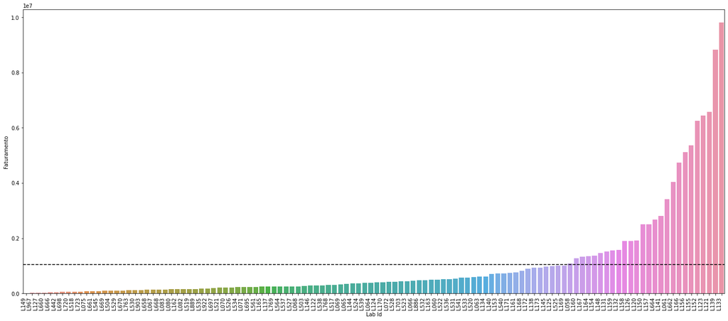

```python
media_faturamento = df_labs["Faturamento"].mean()
plt.figure(figsize=(24, 10))
geo = sns.barplot(data=df_labs.sort_values(by="Faturamento"), x="Lab Id", y="Faturamento")
plt.axhline(media_faturamento, 0, 1, color="black", **{"ls": "--"})
plt.setp(plt.gca().get_xticklabels(), rotation=90, horizontalalignment='right')
plt.show
```

Seria interessante escolher apenas os laboratórios acima da média de faturamento, porém outros aspectos têm que ser levados em consideração e essa medida pode ser um pouco enganosa de certa forma. Pode ser que estejam com um faturamento altíssimo, mas podem estar trabalhando com uma margem pequena para conseguir competir no mercado ou estarem operando no prejuízo.

## Distribuição geográfica do faturamento

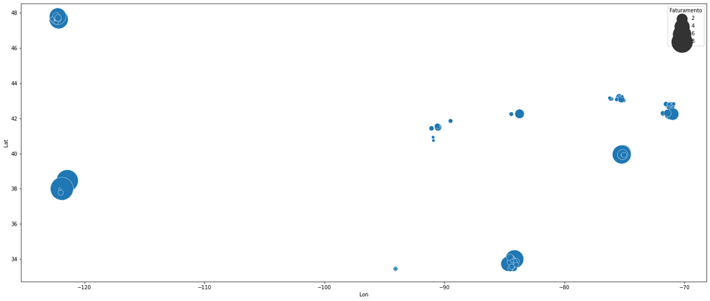

```python
plt.figure(figsize=(24,10))
sns.scatterplot(data=df_labs, x="Lon", y="Lat", size="Faturamento", sizes=(20, 2000))
```

Esse gráfico ajuda a entender um pouco melhor como a posição geográfica afeta no faturamento dos laboratórios. Sendo bastante interessante trabalhar com laboratórios mais isolados, porém com uma quantidade significativa de faturamento. Além disso, pode se notar que alguns laboratórios se sobressasaem mesmo com uma alta quantidade de laboratórios, o que indica um domínio desses laboratórios nessas regiões.

## Distribuição geográfica do ticket médio

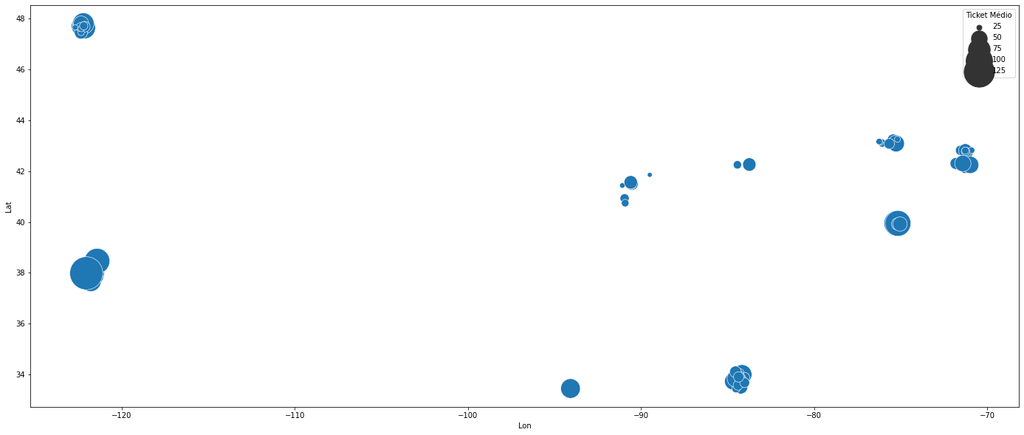

```python
plt.figure(figsize=(24,10))
sns.scatterplot(data=df_labs, x="Lon", y="Lat", size="Ticket Médio", sizes=(20, 2000))
```

## Distribuição geográfica do número de exames

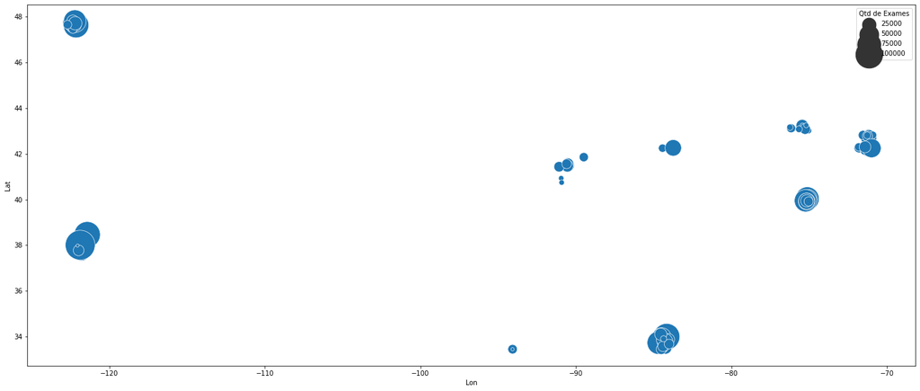

```python
plt.figure(figsize=(24,10))
sns.scatterplot(data=df_labs, x="Lon", y="Lat", size="Qtd de Exames", sizes=(20, 2000))
```

## Ticket médio x Número de exames

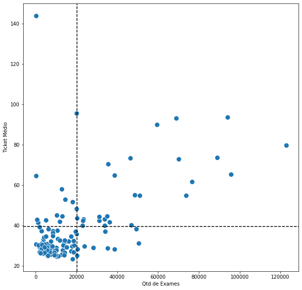

```python
media_numero_exames = df_labs["Qtd de Exames"].mean()
media_ticket_medio = df_labs["Ticket Médio"].mean()
plt.figure(figsize=(10, 10))
sns.scatterplot(data=df_labs, x="Qtd de Exames", y="Ticket Médio", s=100)
plt.axhline(media_ticket_medio, 0, 1, color="black", **{"ls": "--"})
plt.axvline(media_numero_exames, 0, 1, color="black", **{"ls": "--"})
```

O gráfico é dividido em quatro áreas com características distintas:

- Superior direito: Possuem um alto ticket médio e um alto número de exames (Ótimo);
- Superior esquerdo: Possuem um alto ticket médio e um baixo número de exames (Bom);
- Inferior direito: Possuem um baixo ticket médio e um alto número de exames (Bom);
- Inferior esquerdo: Possuem um baixo ticket médio e um baixo número de exames (Ruim).

## Número de exames para mulheres e homens

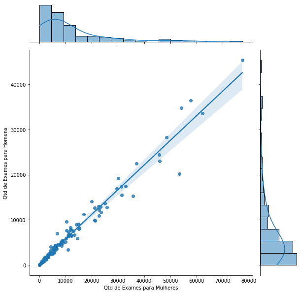

```python
sns.jointplot(data=df_labs, x="Qtd de Exames para Mulheres", y="Qtd de Exames para Homens", kind="reg", height=8.4)
```

- Identificação de um padrão de comportamento da proporção de exames para mulheres e para homens
- Existindo uma tendência para uma maior quantidade de mulheres realizando os exames do que homens

## Custo total dos exames por laboratório

```
<function matplotlib.pyplot.show(close=None, block=None)>
```

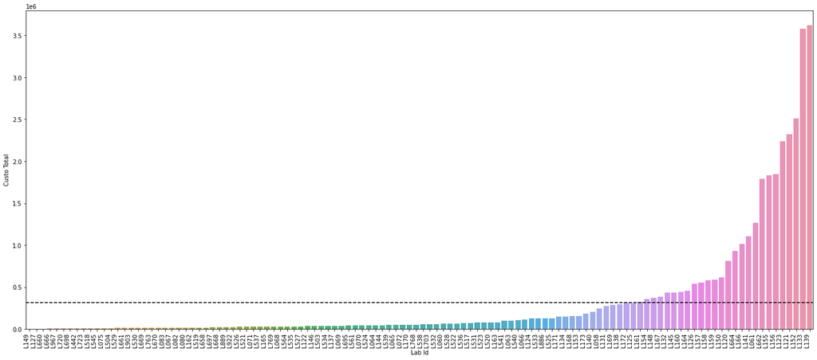

```python
media_custo_total = df_labs["Custo Total"].mean()
plt.figure(figsize=(24, 10))
geo = sns.barplot(data=df_labs.sort_values(by="Custo Total"), x="Lab Id", y="Custo Total")
plt.axhline(media_custo_total, 0, 1, color="black", **{"ls": "--"})
plt.setp(plt.gca().get_xticklabels(), rotation=90, horizontalalignment='right')
plt.show
```

## Custo médio por laboratório

```
<function matplotlib.pyplot.show(close=None, block=None)>
```

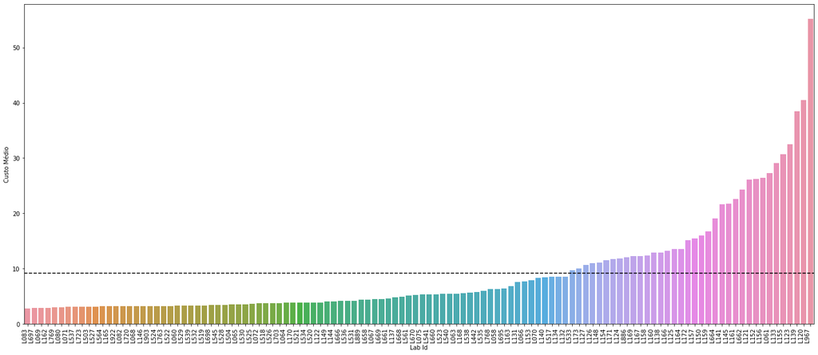

```python
media_custo_medio = df_labs["Custo Médio"].mean()
plt.figure(figsize=(24, 10))
geo = sns.barplot(data=df_labs.sort_values(by="Custo Médio"), x="Lab Id", y="Custo Médio")
plt.axhline(media_custo_medio, 0, 1, color="black", **{"ls": "--"})
plt.setp(plt.gca().get_xticklabels(), rotation=90, horizontalalignment='right')
plt.show
```

## Coeficiente de custo por laboratório

```
<function matplotlib.pyplot.show(close=None, block=None)>
```

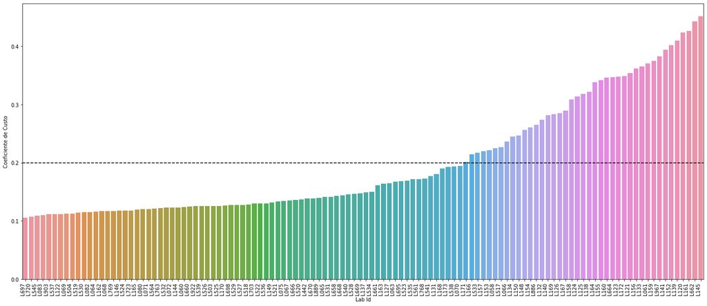

```python
media_coeficiente_custo = df_labs["Coeficiente de Custo"].mean()
plt.figure(figsize=(24, 10))
geo = sns.barplot(data=df_labs.sort_values(by="Coeficiente de Custo"), x="Lab Id", y="Coeficiente de Custo")
plt.axhline(media_coeficiente_custo, 0, 1, color="black", **{"ls": "--"})
plt.setp(plt.gca().get_xticklabels(), rotation=90, horizontalalignment='right')
plt.show
```

## Quantidade de exames diferentes por laboratório

```
<function matplotlib.pyplot.show(close=None, block=None)>
```

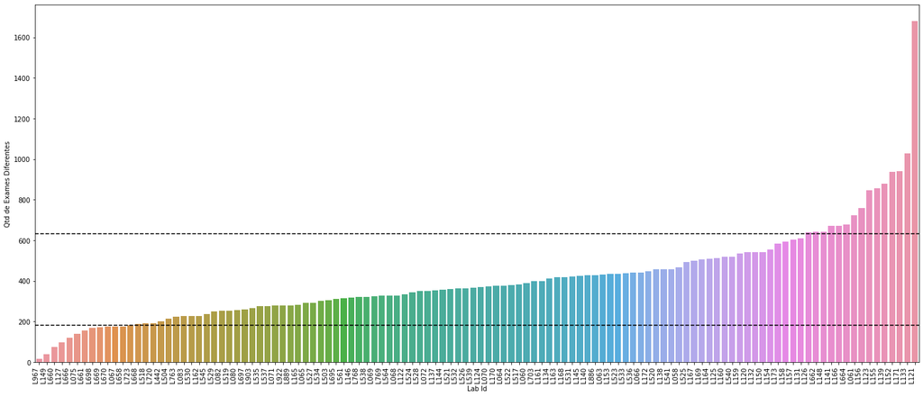

```python
media_exames_diferentes = df_labs["Qtd de Exames Diferentes"].mean()
desvio_exames_diferentes = df_labs["Qtd de Exames Diferentes"].std()
plt.figure(figsize=(24, 10))
geo = sns.barplot(data=df_labs.sort_values(by="Qtd de Exames Diferentes"), x="Lab Id", y="Qtd de Exames Diferentes")
plt.axhline(media_exames_diferentes+desvio_exames_diferentes, 0, 1, color="black", **{"ls": "--"})
plt.axhline(media_exames_diferentes-desvio_exames_diferentes, 0, 1, color="black", **{"ls": "--"})
plt.setp(plt.gca().get_xticklabels(), rotation=90, horizontalalignment='right')
plt.show
```

## Quantidade de categorias diferentes por laboratório

```
<function matplotlib.pyplot.show(close=None, block=None)>
```

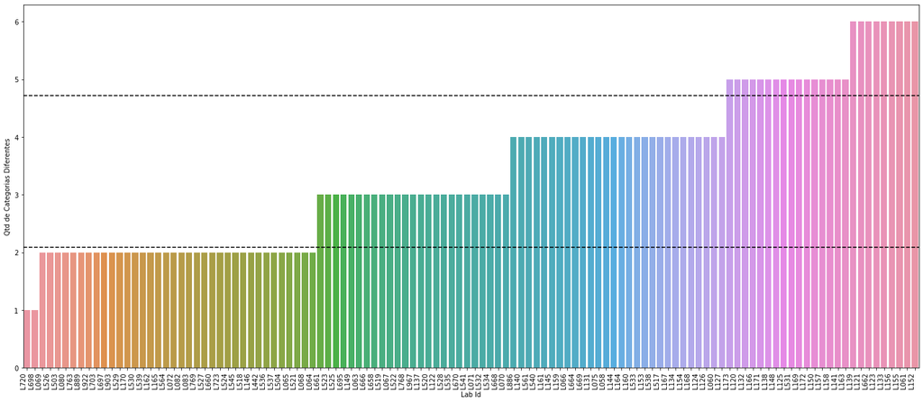

```python
media_categorias_diferentes = df_labs["Qtd de Categorias Diferentes"].mean()
desvio_categorias_diferentes = df_labs["Qtd de Categorias Diferentes"].std()
plt.figure(figsize=(24, 10))
geo = sns.barplot(data=df_labs.sort_values(by="Qtd de Categorias Diferentes"), x="Lab Id", y="Qtd de Categorias Diferentes")
plt.axhline(media_categorias_diferentes+desvio_categorias_diferentes, 0, 1, color="black", **{"ls": "--"})
plt.axhline(media_categorias_diferentes-desvio_categorias_diferentes, 0, 1, color="black", **{"ls": "--"})
plt.setp(plt.gca().get_xticklabels(), rotation=90, horizontalalignment='right')
plt.show
```

## Quantidade de famílias diferentes por laboratório

```
<function matplotlib.pyplot.show(close=None, block=None)>
```

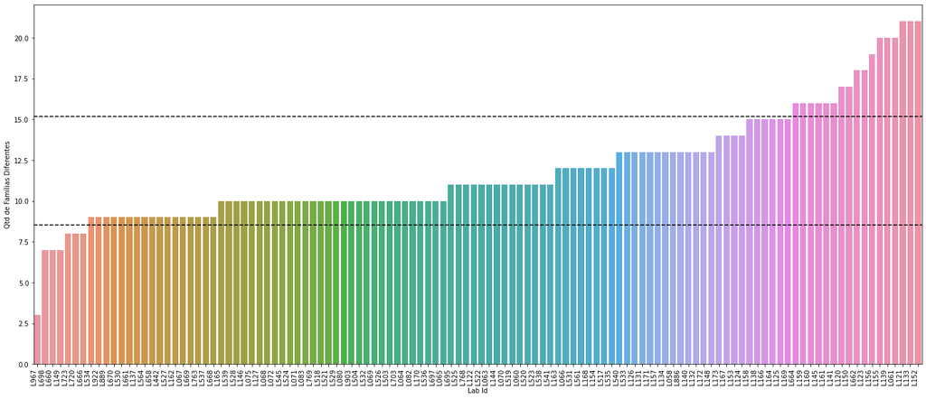

```python
media_familias_diferentes = df_labs["Qtd de Famílias Diferentes"].mean()
desvio_familias_diferentes = df_labs["Qtd de Famílias Diferentes"].std()
plt.figure(figsize=(24, 10))
geo = sns.barplot(data=df_labs.sort_values(by="Qtd de Famílias Diferentes"), x="Lab Id", y="Qtd de Famílias Diferentes")
plt.axhline(media_familias_diferentes+desvio_familias_diferentes, 0, 1, color="black", **{"ls": "--"})
plt.axhline(media_familias_diferentes-desvio_familias_diferentes, 0, 1, color="black", **{"ls": "--"})
plt.setp(plt.gca().get_xticklabels(), rotation=90, horizontalalignment='right')
plt.show
```

## Quantidade de especialidades diferentes por laboratório

```
<function matplotlib.pyplot.show(close=None, block=None)>
```

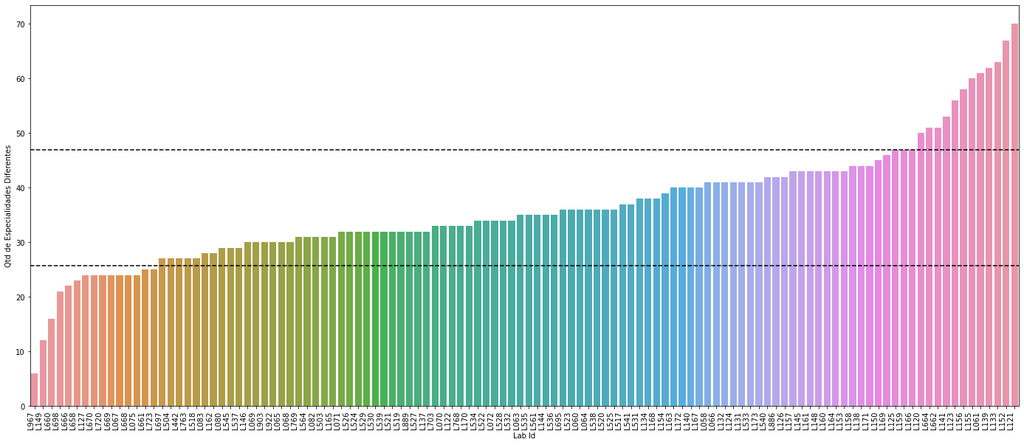

```python
media_especialidades_diferentes = df_labs["Qtd de Especialidades Diferentes"].mean()
desvio_especialidades_diferentes = df_labs["Qtd de Especialidades Diferentes"].std()
plt.figure(figsize=(24, 10))
geo = sns.barplot(data=df_labs.sort_values(by="Qtd de Especialidades Diferentes"), x="Lab Id", y="Qtd de Especialidades Diferentes")
plt.axhline(media_especialidades_diferentes+desvio_especialidades_diferentes, 0, 1, color="black", **{"ls": "--"})
plt.axhline(media_especialidades_diferentes-desvio_especialidades_diferentes, 0, 1, color="black", **{"ls": "--"})
plt.setp(plt.gca().get_xticklabels(), rotation=90, horizontalalignment='right')
plt.show
```

## 4. Seleção dos dados

Com os dados que temos dos laboratórios, serão selecionados aqueles que possuem valores interessantes para se ter em um novo laboratório. As métricas que foram selecionadas levam em consideração o funcionamento de negócios, como:

- Ticket Médio acima da média: O Ticket Médio é o valor médio de cada exame realizado por cada cliente. Ter um ticket médio acima da média é importante para qualquer tipo de negócio, pois isso significa que a empresa está gerando mais receita por transação e, consequentemente, maximizando seu lucro.
- Número de exames acima da média: É fundamental que o laboratório tenha uma quantidade considerável de número de exames para que se tenha um aumento da receita, uma fácil expansão de mercado, uma boa eficiência operacional e um fortalecimento da rede de laboratórios.
- Coeficiente de custo menor que a média: Essa métrica indica uma alta taxa de sobrevivência de um determinado laboratório, uma maior flexibilidade financeira e uma maior satisfação para os líderes da rede de laboratórios.
- Quantidade de exames diferentes perto da média: Existem diversos problemas relacionados à pouca variedade de exames que seriam perda de vendas, perda de oportunidades de cross-selling, dificuldade de atender a demanda dos clientes, perda de vantagem competitiva e limitação do crescimento do negócio. Além disso, existem diversos problemas relacionados à alta variedade de exames seriam uma complexidade de gerenciamento, aumento dos custos, dificuldade de ter um foco comercial e um desperdício maior de recursos.

```python
# Selecionar os laboratórios do Dataframe que possuem características que são desejáveis para um novo laboratório
df_labs_selecionados = df_labs[(df_labs["Ticket Médio"] >= media_ticket_medio) &
                               (df_labs["Qtd de Exames"] >= media_numero_exames) &
                               (df_labs["Coeficiente de Custo"] <= media_coeficiente_custo) &
                               (df_labs["Qtd de Exames Diferentes"] <= media_exames_diferentes+desvio_exames_diferentes) &
                               (df_labs["Qtd de Exames Diferentes"] >= media_exames_diferentes-desvio_exames_diferentes)]
df_labs_selecionados.head()
```

|  | Zipcode | Lab Id | Address | Lat | Lon | Qtd de Clientes | Faturamento | Qtd de Exames | Ticket Médio | Qtd de Exames para Mulheres | Qtd de Exames para Homens | Custo Total | Custo Médio | Qtd de Exames Diferentes | Qtd de Categorias Diferentes | Qtd de Famílias Diferentes | Qtd de Especialidades Diferentes | Coeficiente de Custo |
| --- | --- | --- | --- | --- | --- | --- | --- | --- | --- | --- | --- | --- | --- | --- | --- | --- | --- | --- |
| 90 | 48104.0 | L131 | 1000 E STADIUM, ANN ARBOR, MI 48104 | 42.260788 | -83.739119 | 6833 | 1514912.52 | 36232 | 41.811452 | 23312 | 12920 | 273954.39 | 7.561117 | 609 | 4 | 13 | 41 | 0.180838 |

```python
# Informações demográficas do ZIP CODE do laboratório escolhido
df_demographic[df_demographic["Geographic Area Name"] == "ZCTA5 48104"]
```

|  | Id | Geographic Area Name | TotalPopulation | SexRatio(males per 100 females) | Population_Under5Years | Population_5to9Years | Population_10to14Years | Population_15to19Years | Population_20to24Years | Population_25to34Years | Population_35to44Years | Population_45to54Years | Population_55to59Years | Population_60to64Years | Population_65to74Years | Population_75to84Years | Population_85YearsAndOver | MedianAgeInYears |
| --- | --- | --- | --- | --- | --- | --- | --- | --- | --- | --- | --- | --- | --- | --- | --- | --- | --- | --- |
| 13239 | 8600000US48104 | ZCTA5 48104 | 43369 | 101.8 | 1088 | 1132 | 961 | 5106 | 16330 | 6785 | 2875 | 2437 | 1516 | 1432 | 2353 | 1058 | 296 | 23.0 |

```python
# Informações econômicas do ZIP CODE do laboratório escolhido
df_economic[df_economic["Geographic Area Name"] == "ZCTA5 48104"]
```

|  | id | Geographic Area Name | TotalHouseholds_LessThan$10.000 | TotalHouseholds_$10.000to$14.999 | TotalHouseholds_$15.000to$24.999 | TotalHouseholds_$25.000to$34.999 | TotalHouseholds_$35.000to$49.999 | TotalHouseholds_$50.000to$74.999 | TotalHouseholds_$75.000to$99.999 | TotalHouseholds_$100.000to$149.999 | TotalHouseholds_$150.000to$199.999 | TotalHouseholds_$200.000OrMore |
| --- | --- | --- | --- | --- | --- | --- | --- | --- | --- | --- | --- | --- |
| 13239 | 8600000US48104 | ZCTA5 48104 | 2164 | 939 | 1299 | 1252 | 1662 | 2372 | 1536 | 1879 | 1264 | 2019 |

```python
# Pegar as informações do ZIP CODE do laboratório selecionado
df_zip_separado = df_zip_codes[df_zip_codes["Geographic Area Name"] == 48104.0]
df_zip_separado.head()
```

|  | Geographic Area Name | TotalPopulation | SexRatio(males per 100 females) | Population_Under5Years | Population_5to9Years | Population_10to14Years | Population_15to19Years | Population_20to24Years | Population_25to34Years | Population_35to44Years | ... | TotalHouseholds_LessThan$10.000 | TotalHouseholds_$10.000to$14.999 | TotalHouseholds_$15.000to$24.999 | TotalHouseholds_$25.000to$34.999 | TotalHouseholds_$35.000to$49.999 | TotalHouseholds_$50.000to$74.999 | TotalHouseholds_$75.000to$99.999 | TotalHouseholds_$100.000to$149.999 | TotalHouseholds_$150.000to$199.999 | TotalHouseholds_$200.000OrMore |
| --- | --- | --- | --- | --- | --- | --- | --- | --- | --- | --- | --- | --- | --- | --- | --- | --- | --- | --- | --- | --- | --- |
| 13239 | 48104.0 | 43369 | 101.8 | 1088 | 1132 | 961 | 5106 | 16330 | 6785 | 2875 | ... | 2164 | 939 | 1299 | 1252 | 1662 | 2372 | 1536 | 1879 | 1264 | 2019 |

1 rows × 27 columns

## 5. Conclusão

```python
# Remover as linhas de ZIP CODES que já possuem laboratórios na rede
df_zip_codes_sem_laboratorios = df_zip_codes[~df_zip_codes["Geographic Area Name"].isin(df_labs["Zipcode"].unique())]
df_zip_codes_sem_laboratorios.head()
```

|  | Geographic Area Name | TotalPopulation | SexRatio(males per 100 females) | Population_Under5Years | Population_5to9Years | Population_10to14Years | Population_15to19Years | Population_20to24Years | Population_25to34Years | Population_35to44Years | ... | TotalHouseholds_LessThan$10.000 | TotalHouseholds_$10.000to$14.999 | TotalHouseholds_$15.000to$24.999 | TotalHouseholds_$25.000to$34.999 | TotalHouseholds_$35.000to$49.999 | TotalHouseholds_$50.000to$74.999 | TotalHouseholds_$75.000to$99.999 | TotalHouseholds_$100.000to$149.999 | TotalHouseholds_$150.000to$199.999 | TotalHouseholds_$200.000OrMore |
| --- | --- | --- | --- | --- | --- | --- | --- | --- | --- | --- | --- | --- | --- | --- | --- | --- | --- | --- | --- | --- | --- |
| 0 | 35004.0 | 12045 | 94.1 | 805 | 1075 | 898 | 477 | 578 | 2088 | 1628 | ... | 198 | 71 | 298 | 513 | 647 | 1117 | 529 | 945 | 245 | 61 |
| 1 | 35005.0 | 7344 | 86.1 | 504 | 453 | 511 | 499 | 214 | 788 | 795 | ... | 188 | 184 | 318 | 293 | 353 | 562 | 299 | 407 | 67 | 26 |
| 2 | 35006.0 | 2883 | 108.2 | 96 | 153 | 303 | 129 | 156 | 183 | 367 | ... | 71 | 20 | 117 | 104 | 154 | 176 | 124 | 194 | 51 | 7 |
| 3 | 35007.0 | 26332 | 95.0 | 1936 | 1992 | 1837 | 1762 | 1376 | 3119 | 3849 | ... | 396 | 208 | 670 | 462 | 1173 | 1854 | 1578 | 2224 | 473 | 254 |
| 4 | 35010.0 | 20613 | 90.5 | 1306 | 1465 | 944 | 1217 | 1128 | 2513 | 2106 | ... | 700 | 610 | 1093 | 957 | 1056 | 1512 | 807 | 749 | 254 | 249 |

5 rows × 27 columns

```python
# Pegar os três ZIP CODES para serem os escolhidos
df_zip_codes_selecionados = df_zip_codes_sem_laboratorios[
    (df_zip_codes_sem_laboratorios["TotalPopulation"] <=
     df_zip_separado["TotalPopulation"].mean()+df_zip_codes["TotalPopulation"].std()) &
    (df_zip_codes_sem_laboratorios["TotalPopulation"] >=
     df_zip_separado["TotalPopulation"].mean()-df_zip_codes["TotalPopulation"].std()) &
    (df_zip_codes_sem_laboratorios["Population_20to24Years"] <=
     df_zip_separado["Population_20to24Years"].mean()+df_zip_codes["Population_20to24Years"].std()) &
    (df_zip_codes_sem_laboratorios["Population_20to24Years"] >=
     df_zip_separado["Population_20to24Years"].mean()-df_zip_codes["Population_20to24Years"].std()) &
    (df_zip_codes_sem_laboratorios["TotalHouseholds_$50.000to$74.999"] <=
     df_zip_separado["TotalHouseholds_$50.000to$74.999"].mean()+df_zip_codes["TotalHouseholds_$50.000to$74.999"].std()) &
    (df_zip_codes_sem_laboratorios["TotalHouseholds_$50.000to$74.999"] >=
     df_zip_separado["TotalHouseholds_$50.000to$74.999"].mean()-df_zip_codes["TotalHouseholds_$50.000to$74.999"].std())]
print(len(df_zip_codes_selecionados))
df_zip_codes_selecionados.head()
```

```
5
```

|  | Geographic Area Name | TotalPopulation | SexRatio(males per 100 females) | Population_Under5Years | Population_5to9Years | Population_10to14Years | Population_15to19Years | Population_20to24Years | Population_25to34Years | Population_35to44Years | ... | TotalHouseholds_LessThan$10.000 | TotalHouseholds_$10.000to$14.999 | TotalHouseholds_$15.000to$24.999 | TotalHouseholds_$25.000to$34.999 | TotalHouseholds_$35.000to$49.999 | TotalHouseholds_$50.000to$74.999 | TotalHouseholds_$75.000to$99.999 | TotalHouseholds_$100.000to$149.999 | TotalHouseholds_$150.000to$199.999 | TotalHouseholds_$200.000OrMore |
| --- | --- | --- | --- | --- | --- | --- | --- | --- | --- | --- | --- | --- | --- | --- | --- | --- | --- | --- | --- | --- | --- |
| 3331 | 95616.0 | 52212 | 86.3 | 1232 | 1450 | 1433 | 9191 | 16731 | 6900 | 3335 | ... | 2653 | 1042 | 1397 | 1155 | 1628 | 2423 | 1243 | 2051 | 1572 | 2138 |
| 16207 | 65201.0 | 47090 | 94.5 | 1538 | 1330 | 1566 | 7269 | 15282 | 7124 | 3624 | ... | 2855 | 942 | 2011 | 2341 | 2231 | 2527 | 1539 | 1468 | 791 | 484 |
| 21903 | 43201.0 | 34232 | 122.5 | 919 | 668 | 444 | 2854 | 15999 | 7956 | 1932 | ... | 2077 | 883 | 1694 | 1537 | 1528 | 1506 | 1389 | 1024 | 493 | 502 |
| 29472 | 84606.0 | 37080 | 99.5 | 2035 | 1472 | 1284 | 3224 | 16805 | 6533 | 2460 | ... | 711 | 1067 | 1553 | 1657 | 1412 | 1901 | 881 | 845 | 263 | 272 |
| 32279 | 53703.0 | 34766 | 109.4 | 313 | 120 | 230 | 2351 | 16250 | 8459 | 2153 | ... | 2303 | 1236 | 1993 | 1895 | 2163 | 2450 | 1395 | 1550 | 649 | 995 |

5 rows × 27 columns

```python
df_zip_codes_selecionados = df_zip_codes_selecionados.sort_values(by="TotalPopulation", ascending=False)
df_zip_codes_selecionados.head()
```

|  | Geographic Area Name | TotalPopulation | SexRatio(males per 100 females) | Population_Under5Years | Population_5to9Years | Population_10to14Years | Population_15to19Years | Population_20to24Years | Population_25to34Years | Population_35to44Years | ... | TotalHouseholds_LessThan$10.000 | TotalHouseholds_$10.000to$14.999 | TotalHouseholds_$15.000to$24.999 | TotalHouseholds_$25.000to$34.999 | TotalHouseholds_$35.000to$49.999 | TotalHouseholds_$50.000to$74.999 | TotalHouseholds_$75.000to$99.999 | TotalHouseholds_$100.000to$149.999 | TotalHouseholds_$150.000to$199.999 | TotalHouseholds_$200.000OrMore |
| --- | --- | --- | --- | --- | --- | --- | --- | --- | --- | --- | --- | --- | --- | --- | --- | --- | --- | --- | --- | --- | --- |
| 3331 | 95616.0 | 52212 | 86.3 | 1232 | 1450 | 1433 | 9191 | 16731 | 6900 | 3335 | ... | 2653 | 1042 | 1397 | 1155 | 1628 | 2423 | 1243 | 2051 | 1572 | 2138 |
| 16207 | 65201.0 | 47090 | 94.5 | 1538 | 1330 | 1566 | 7269 | 15282 | 7124 | 3624 | ... | 2855 | 942 | 2011 | 2341 | 2231 | 2527 | 1539 | 1468 | 791 | 484 |
| 29472 | 84606.0 | 37080 | 99.5 | 2035 | 1472 | 1284 | 3224 | 16805 | 6533 | 2460 | ... | 711 | 1067 | 1553 | 1657 | 1412 | 1901 | 881 | 845 | 263 | 272 |
| 32279 | 53703.0 | 34766 | 109.4 | 313 | 120 | 230 | 2351 | 16250 | 8459 | 2153 | ... | 2303 | 1236 | 1993 | 1895 | 2163 | 2450 | 1395 | 1550 | 649 | 995 |
| 21903 | 43201.0 | 34232 | 122.5 | 919 | 668 | 444 | 2854 | 15999 | 7956 | 1932 | ... | 2077 | 883 | 1694 | 1537 | 1528 | 1506 | 1389 | 1024 | 493 | 502 |

5 rows × 27 columns

Desses 5 ZIP CODES selecionados que possuem características similares ao ZIP CODE do laboratório que foi separado dos demais por possuir métricas fundamentais que comprovam o ótimo funcionamento, foram escolhidos os TRÊS ZIP CODES que possuem maior população, que são:

- 95616
- 65201
- 84606